# 碳排放管理對於企業股價之影響

5/17/2022

## 研究動機

分析師報告中證實MSCI ACWI ESG Leaders Index的確在2020年疫情爆發之後較MSCI ACWI Index取得相對好的報酬。近期歐盟祭出2050年碳中和目標與一系列政策，企業因此面臨低碳轉型風險，因此我們希望將樣本池鎖定歐盟企業，且著重於ESG中的碳排放管理指標，期許能夠針對這個課題得出一些新發現。

## 分析與結果

### Exploratory Data Analysis

|  | TotalReturn_2y | Industry | CARBON_EMISSIONS_SCORE | IVA_COMPANY_RATING | INDUSTRY_ADJUSTED_SCORE | GOVERNANCE_PILLAR_SCORE |
| --- | --- | --- | --- | --- | --- | --- |
| 1 | -1.16644779330294 | Communication Services | 10 | BBB | 5.4 | 5.2 |
| 2 | 110.52874330509 | Financials | 10 | AA | 7.9 | 5.1 |
| 3 | 99.2112374593959 | Financials | 10 | AAA | 9.1 | 4.8 |
| 4 | 124.059284753792 | Health Care | 9.7 | AA | 8.1 | 5.4 |
| 5 | 80.6995288093421 | Information Technology | 10 | AA | 8.57 | 7.4 |
| 6 | 113.03201859783 | Materials | 7.4 | AAA | 9.1 | 7.1 |
| 7 | 107.03763019947 | Health Care | 10 | BBB | 5.5 | 4.7 |
| 8 | 182.618364397963 | Information Technology | 10 | AA | 7.4 | 6.9 |
| 9 | 44.2401553245642 | Consumer Staples | 10 | A | 6.2 | 4.6 |
| 10 | 132.656866047014 | Information Technology | 8.5 | BBB | 5.5 | 4.6 |

[output cut: 310 more lines]

#### 1. Correlation Plots

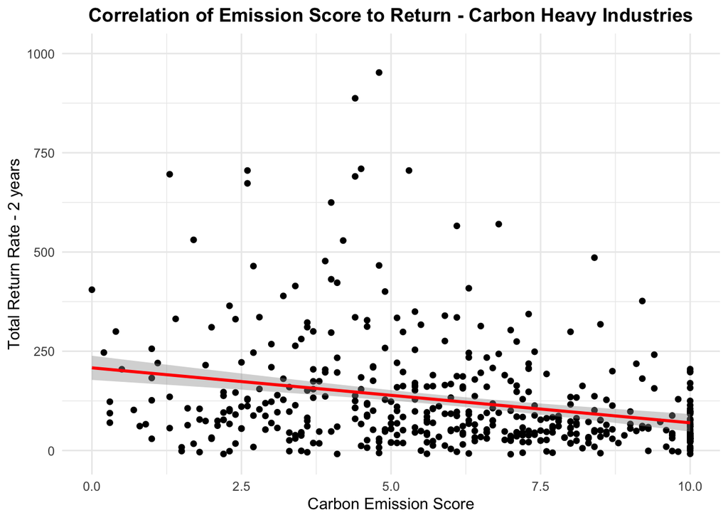

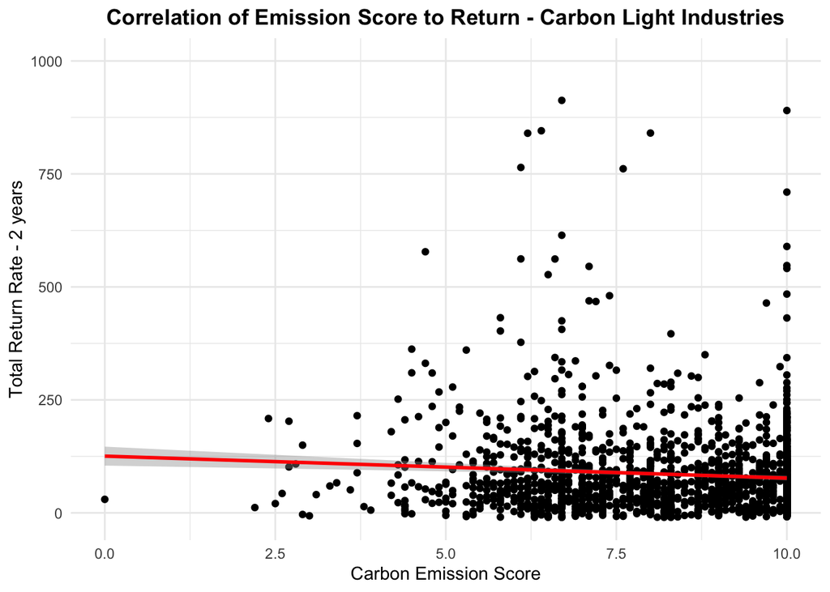

#### 2. Avergae Emission Score Across EU

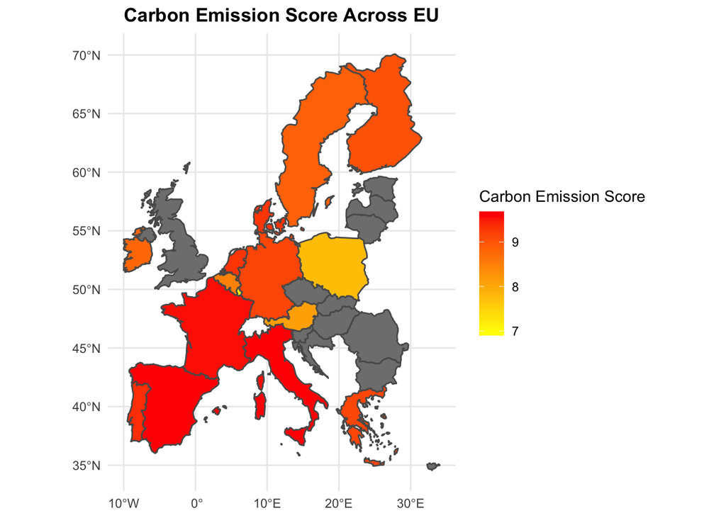

### Modeling

#### Model Results

##### 1. Linear Model Result

```
##
## Call:
## lm(formula = TotalReturn_2y ~ IVA_COMPANY_RATING + INDUSTRY_ADJUSTED_SCORE +
##     GOVERNANCE_PILLAR_SCORE + CARBON_EMISSIONS_SCORE + Industry,
##     data = heavy_train)
##
## Residuals:
##     Min      1Q  Median      3Q     Max
## -209.16  -86.16  -43.93   18.93 2168.31
##
## Coefficients:
##                         Estimate Std. Error t value Pr(>|t|)
## (Intercept)              309.497    143.109   2.163   0.0311 *
## IVA_COMPANY_RATINGAA     -27.509     42.833  -0.642   0.5211
## IVA_COMPANY_RATINGAAA     -8.713     77.247  -0.113   0.9103
## IVA_COMPANY_RATINGB      -86.623    101.055  -0.857   0.3918
## IVA_COMPANY_RATINGBB     -84.282     71.065  -1.186   0.2363
## IVA_COMPANY_RATINGBBB      3.597     42.413   0.085   0.9325
## IVA_COMPANY_RATINGCCC   -164.480    137.015  -1.200   0.2307
## INDUSTRY_ADJUSTED_SCORE  -20.674     23.366  -0.885   0.3768
## GOVERNANCE_PILLAR_SCORE    6.762      7.877   0.858   0.3912
## CARBON_EMISSIONS_SCORE    -6.389      5.085  -1.256   0.2097
## IndustryMaterials        -15.058     24.623  -0.612   0.5412
## IndustryUtilities        -38.844     28.921  -1.343   0.1800
## ---
## Signif. codes:  0 '***' 0.001 '**' 0.01 '*' 0.05 '.' 0.1 ' ' 1
##
## Residual standard error: 186.5 on 411 degrees of freedom
## Multiple R-squared:  0.05353,    Adjusted R-squared:  0.02819
## F-statistic: 2.113 on 11 and 411 DF,  p-value: 0.01852
```

```
##
## Call:
## lm(formula = TotalReturn_2y ~ IVA_COMPANY_RATING + INDUSTRY_ADJUSTED_SCORE +
##     GOVERNANCE_PILLAR_SCORE + CARBON_EMISSIONS_SCORE + Industry,
##     data = light_train, na.action = na.omit)
##
## Residuals:
##     Min      1Q  Median      3Q     Max
## -199.37  -60.38  -19.63   23.93 2901.11
##
## Coefficients:
##                                Estimate Std. Error t value Pr(>|t|)
## (Intercept)                      47.169     59.027   0.799 0.424323
## IVA_COMPANY_RATINGAA             -9.005     15.692  -0.574 0.566102
## IVA_COMPANY_RATINGAAA           -20.020     30.353  -0.660 0.509613
## IVA_COMPANY_RATINGB              10.086     38.559   0.262 0.793679
## IVA_COMPANY_RATINGBB             -4.380     26.954  -0.162 0.870933
## IVA_COMPANY_RATINGBBB             8.100     16.128   0.502 0.615576
## IVA_COMPANY_RATINGCCC            37.840     54.187   0.698 0.485055
## INDUSTRY_ADJUSTED_SCORE           3.022      8.430   0.358 0.720034
## GOVERNANCE_PILLAR_SCORE           1.793      3.014   0.595 0.552030
## CARBON_EMISSIONS_SCORE           -2.483      2.372  -1.047 0.295219
## IndustryConsumer Discretionary   33.965     15.819   2.147 0.031897 *
## IndustryConsumer Staples        -20.376     16.623  -1.226 0.220408
## IndustryFinancials               34.516     15.003   2.301 0.021511 *
## IndustryHealth Care              15.628     16.297   0.959 0.337691
## IndustryIndustrials              57.072     15.115   3.776 0.000164 ***
## IndustryInformation Technology   44.555     15.424   2.889 0.003911 **
## IndustryReal Estate              -5.495     18.395  -0.299 0.765190
## ---
## Signif. codes:  0 '***' 0.001 '**' 0.01 '*' 0.05 '.' 0.1 ' ' 1
##
## Residual standard error: 152.9 on 2008 degrees of freedom
##   (7 observations deleted due to missingness)
## Multiple R-squared:  0.02906,    Adjusted R-squared:  0.02132
## F-statistic: 3.756 on 16 and 2008 DF,  p-value: 6.56e-07
```

##### 2. Random Forest Result

```
##
## Call:
##  randomForest(formula = TotalReturn_2y ~ IVA_COMPANY_RATING +      INDUSTRY_ADJUSTED_SCORE + GOVERNANCE_PILLAR_SCORE + CARBON_EMISSIONS_SCORE +      Industry, data = heavy_train, control = rpart.control(cp = 0.002,      minsplit = 30), importance = TRUE)
##                Type of random forest: regression
##                      Number of trees: 500
## No. of variables tried at each split: 1
##
##           Mean of squared residuals: 35526.41
##                     % Var explained: 0.51
```

```
##
## Call:
##  randomForest(formula = TotalReturn_2y ~ IVA_COMPANY_RATING +      INDUSTRY_ADJUSTED_SCORE + GOVERNANCE_PILLAR_SCORE + CARBON_EMISSIONS_SCORE +      Industry, data = light_train, control = rpart.control(cp = 0.002,      minsplit = 30), importance = TRUE, na.action = na.omit)
##                Type of random forest: regression
##                      Number of trees: 500
## No. of variables tried at each split: 1
##
##           Mean of squared residuals: 23971.04
##                     % Var explained: -0.43
```

##### 3. Compare Out-of-Sample Performance

```
## [1] 115.2414
```

[output not shown]

```
## [1] 126.2252
```

```
## [1] 96.92479
```